# Weekly Task - 1

Pere Fuster

Table of Contents

```r
library(lubridate)
library(tidyverse)
library(dygraphs)
library(xts)
library(tseries)

knitr::opts_chunk$set(echo = TRUE)
x = read.table(file = "clipboard")
```

## Introduction

For this task I’ve chosen the daily IBM stock price time series, which starts, in May 1961 until Nov 1962.

```r
don = xts(x = as.numeric(x$V2), order.by = ymd(x$V1))

# Make the chart
names(don) = c("Value")

dygraph(don, main = "IBM Stock Prices") %>%
  dyAxis("x", drawGrid = FALSE) %>%
  dySeries("Value", label = "Price") %>%
  dyOptions(stackedGraph = TRUE)
```

[interactive chart not shown]

## Assessing Stationarity

As we’ve seen in class there is no perfect test to assess stationarity in mean and variance, so we are advised to do it visually. Still, we can apply the Dickey Fulley test to evaluate the existence of a trend.

```r
adf.test(x$V2)
```

```
##
##  Augmented Dickey-Fuller Test
##
## data:  x$V2
## Dickey-Fuller = -1.7063, Lag order = 7, p-value = 0.701
## alternative hypothesis: stationary
```

We should as well evaluate the Correlogram (ACF). All evidence suggests the model is AR(1), which is a particular case of Markov Chain.

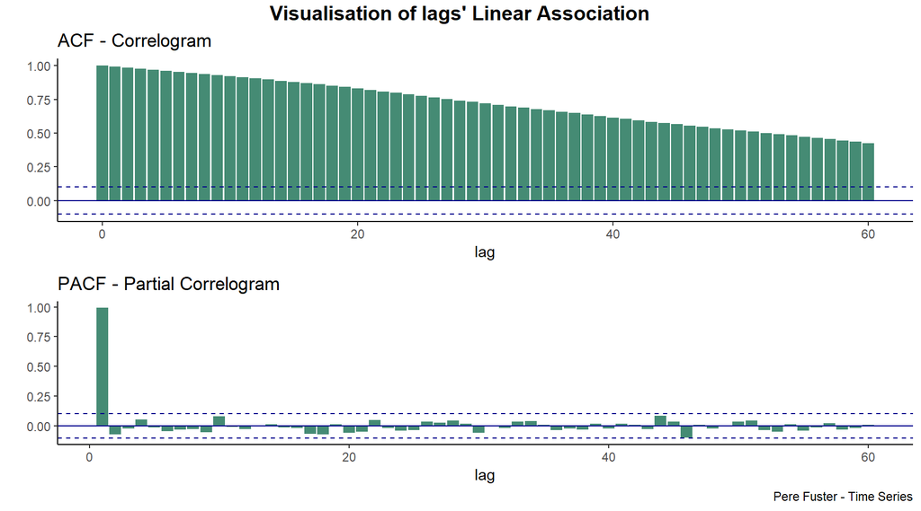

```r
Tm = length(don$Value)
spm.acf = acf(don$Value, lag.max=60, plot=FALSE)
spm.acf = data.frame(lag= 0:60, acf = spm.acf$acf)

a = ggplot(spm.acf, aes(lag, acf)) +
  geom_bar(stat="identity", fill="aquamarine4") +
  geom_hline(yintercept =  1.96 * Tm^(-0.5), color="blue4", linetype="dashed") +
  geom_hline(yintercept = -1.96 * Tm^(-0.5), color="blue4", linetype="dashed") +
  theme_classic() + geom_hline(yintercept = 0, color="blue4") +
    labs(title="ACF - Correlogram") + ylab("")


spm.pacf = pacf(don$Value, lag.max = 60, plot=FALSE)
spm.pacf = data.frame(lag= 1:60, pacf = spm.pacf$acf) # Reminder: k is PACF is defined for positive lags

b = ggplot(spm.pacf, aes(lag, pacf)) +
  geom_bar(stat="identity", fill="aquamarine4") +
  geom_hline(yintercept =  1.96 * Tm^(-0.5), color="blue4", linetype="dashed") +
  geom_hline(yintercept = -1.96 * Tm^(-0.5), color="blue4", linetype="dashed") +
  theme_classic() + geom_hline(yintercept = 0, color="blue4") +
    labs(title="PACF - Partial Correlogram",
       caption="Pere Fuster - Time Series") + ylab("")

library(ggpubr)
X = ggarrange(a, b, ncol = 1,  common.legend = TRUE)
annotate_figure(X,
               top = text_grob("Visualisation of lags' Linear Association", color = "black", face = "bold", size = 14))
```

```r
Box.test(x$V2,lag = 50) # This one, shows no evidence to believe we have a stationary series. There is correlation between the lags, obviously, but that does not mean the series is non-stationary
```

```
##
##  Box-Pierce test
##
## data:  x$V2
## X-squared = 11209, df = 50, p-value < 2.2e-16
```

Yet, despite the fact that we’re not having clear trend in mean, we would also need to evaluate the stationariety in variance (That is, we would have heteroskedastic errors if we consider time a quantitative regressor - right?). I personally don’t think this variance is constant/homoscedastic. Therefore for this time series I would conclude:

1. There is no (clear) trend.
2. The variance of the series is not constant over time.
3. There appears to be periodicity but not seasonality or not regular at all.

## Transforming the series to achieve stationarity

There are several possible transformations that can be used for achieving stationarity in variance. The basic idea is to transform the data such that an originally curved plot is straighter, and at the same time make the variance constant over the whole series.

One frequently used transformation is the logarith, which is more effective when:

- The variance of the series is proportional to the mean of the series (Not the case)
- The mean level of the series changes at a constant percentage (Don’t think it’s the case either)

```r
don = xts(x = diff(log(as.numeric(x$V2))), order.by = ymd(x$V1[1:(length(x$V2)-1)]))

# Make the chartº
names(don) = c("Value")

dygraph(don, main = "IBM Stock Prices after Log-diff transformation ") %>%
  dyAxis("x", drawGrid = FALSE) %>%
  dySeries("Value", label = "Log-Diff Price") %>%
  dyOptions(stackedGraph = TRUE)
```

[interactive chart not shown]

```r
don = xts(x = diff(sqrt(as.numeric(x$V2))), order.by = ymd(x$V1[1:(length(x$V2)-1)]))

# Make the chartº
names(don) = c("Value2")

dygraph(don, main = "IBM Stock Prices after sqrt-diff transformation ") %>%
  dyAxis("x", drawGrid = FALSE) %>%
  dySeries("Value2", label = "Sqrt-Diff Price")%>%
  dyOptions(stackedGraph = TRUE)
```

[interactive chart not shown]

As we can see, we still don’t have stationary in variance. We will need to model this as an heteroskedastic model, since there appears to be little chance I can transform it into homoskedastic with this type of transformations.

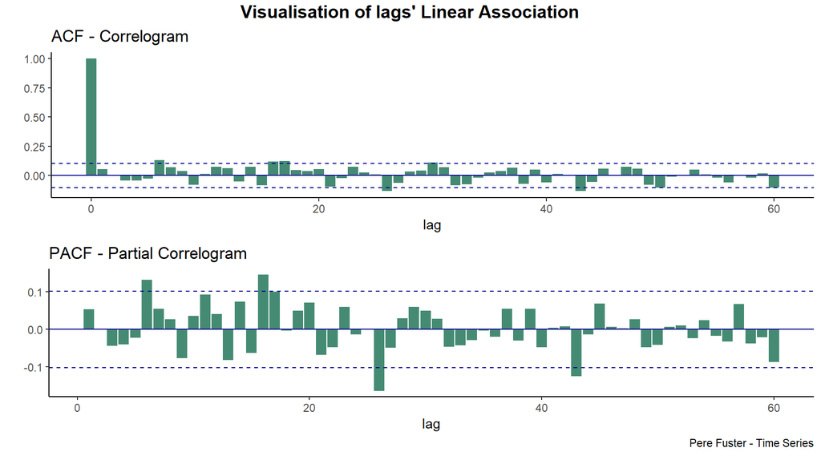

```r
Tm = length(don$Value)
spm.acf = acf(don$Value, lag.max=60, plot=FALSE)
spm.acf = data.frame(lag= 0:60, acf = spm.acf$acf)

a = ggplot(spm.acf, aes(lag, acf)) +
  geom_bar(stat="identity", fill="aquamarine4") +
  geom_hline(yintercept =  1.96 * Tm^(-0.5), color="blue4", linetype="dashed") +
  geom_hline(yintercept = -1.96 * Tm^(-0.5), color="blue4", linetype="dashed") +
  theme_classic() + geom_hline(yintercept = 0, color="blue4") +
    labs(title="ACF - Correlogram") + ylab("")


spm.pacf = pacf(don$Value, lag.max = 60, plot=FALSE)
spm.pacf = data.frame(lag= 1:60, pacf = spm.pacf$acf) # Reminder: k is PACF is defined for positive lags

b = ggplot(spm.pacf, aes(lag, pacf)) +
  geom_bar(stat="identity", fill="aquamarine4") +
  geom_hline(yintercept =  1.96 * Tm^(-0.5), color="blue4", linetype="dashed") +
  geom_hline(yintercept = -1.96 * Tm^(-0.5), color="blue4", linetype="dashed") +
  theme_classic() + geom_hline(yintercept = 0, color="blue4") +
    labs(title="PACF - Partial Correlogram",
       caption="Pere Fuster - Time Series") + ylab("")

library(ggpubr)
X = ggarrange(a, b, ncol = 1,  common.legend = TRUE)
annotate_figure(X,
               top = text_grob("Visualisation of lags' Linear Association", color = "black", face = "bold", size = 14))
```

Now it becomes very difficult to interpret. The log difference has made it something closer to an ARIMA model, if it’s close to any. It appears we would no longer be working with an AR model.

There is a significant dependence for specific lags, such as the 6th or the 26th. We also see that there is overall significant correlation for the first 50 lags as shown below. Additionally, there’s no apparent weekly or monthly periodicity.

```r
Box.test(diff(sqrt(as.numeric(x$V2))),lag = 50)
```

```
##
##  Box-Pierce test
##
## data:  diff(sqrt(as.numeric(x$V2)))
## X-squared = 88.053, df = 50, p-value = 0.000719
```

```r
Box.test(diff(sqrt(as.numeric(x$V2))))
```

```
##
##  Box-Pierce test
##
## data:  diff(sqrt(as.numeric(x$V2)))
## X-squared = 1.0674, df = 1, p-value = 0.3015
```

```r
Box.test(diff(sqrt(as.numeric(x$V2))),lag = 10)
```

```
##
##  Box-Pierce test
##
## data:  diff(sqrt(as.numeric(x$V2)))
## X-squared = 13.802, df = 10, p-value = 0.1822
```

```r
Box.test(diff(sqrt(as.numeric(x$V2))),lag = 5)
```

```
##
##  Box-Pierce test
##
## data:  diff(sqrt(as.numeric(x$V2)))
## X-squared = 2.7872, df = 5, p-value = 0.7327
```

```r
Box.test(diff(sqrt(as.numeric(x$V2))),lag = 1)
```

```
##
##  Box-Pierce test
##
## data:  diff(sqrt(as.numeric(x$V2)))
## X-squared = 1.0674, df = 1, p-value = 0.3015
```

# References

[Visualisation](https://rstudio.github.io/dygraphs/)

[RMarkdown](https://bookdown.org/yihui/rmarkdown/)

[Ref 1: E. E. Holmes, M. D. Scheuerell, and E. J. Ward](https://nwfsc-timeseries.github.io/atsa-labs/sec-boxjenkins-aug-dickey-fuller.html)

[Ref 2: Estadística y Machine Learning con R](https://bookdown.org/content/2274/series-temporales.html#descomposicion-temporal)